# Lecture 14

# A/B Testing

A/B test 是一種透過分析使用者經驗來優化介面的方式，電商用來優化網站的工具，將使用者分成兩組（實驗組與對照組），了解體驗結果，協助商業決策。應用包含網頁、APP介面、廣告或是新產品。實驗測試後的商業策略。

例子：Netflix利用實驗決定圖片，衡量點擊率，提升影片觀看時間 https://medium.com/netflix-techblog/tagged/ab-testing

https://sleeknote.com/blog/a-b-testing-examples

# Steps:

1. 實驗假設：
- 定義問題（如：**提升**分享率、點擊率、瀏覽時；**減少**脫離率、跳出率）
- 產生假說（如：**按鈕**的位置、尺寸、顏色；**版面**配置；**圖片**位置、大小、內容；**促銷方案**）
- 通常只考慮單變數的差異
2. 定義分析目標：找出重要因子
3. 統計模型：實驗設計（實驗組對照組）
4. 決定樣本數量：可接受的誤差、決定信心水準、收集資料
5. 統計分析與檢定：假設檢定 (初統學的那些假設檢定)
6. 實行或更近一步分析

#### Note: 統計上的顯著水準

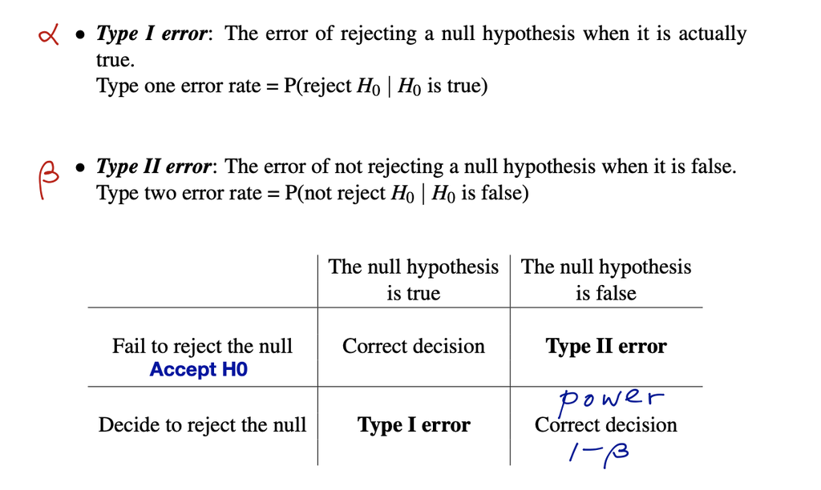

檢定力越強，需要越多樣本

### R codes

決定樣本數量

```
library(pwr)
pwr.anova.test()
pwr.t.test()
pwr.2p.test()
pwr.2p2n.test()
```

檢定

```
prop.test(c(x, y),c(n_x, n_y)) # p1 = x/n_x; p2 = y/n_y #百分比差異
anova() #多組平均數差異
t.test() #平均數差異
chisq.test() #卡方檢定
```

### Example

`load("abtest.Rdata")`

data1:網路商城購買資料，分成實驗組(test = 1)與對照組(test = 0)。

data2:某旅館訂購網站資料，分為新(website=B)舊(website=A)兩介面。